# HW8_QE

Kinsey Reed

4/19/2021

Included in this homework is the same N-mixture modeling dataset introduced in class: • sosp_nmix.csv: counts of song sparrow at each survey. Each row is a site, and each column is a replicate survey. • p_covs_nmix.csv: detection-level covariates recorded at each survey. Each row is a site, and each column is a replicate survey (1 day). xxx.1 represents covariate xxx recorded at survey 1, and xxx.2 represents covariate xxx recorded at survey 2. For this exercise, we will use variables time (hours past midnight that the survey started) and sky (0 = clear skies; 1 = partly cloudy; 2 = overcast; 4 = precipitation). ***no 4’s though • n_covs_nmix.csv: site-level covariates. Defined in the N-Mixture Models lecture, slide 34. For this exercise, we will use size (wetland size in ha) and type (acep = Agricultural Conservation Easement Program wetland; reference = Reference Wetland)

1. Fit an N-mixture model that assumes abundance is a function of wetland size and type, and detection probability is a function of sky and time (5 points).

```r
library(unmarked)
data <- read.csv('sosp_nmix.csv')
head(data)
```

```
##   y1 y2
## 1  0  0
## 2  0  0
## 3  0  1
## 4  0  0
## 5  4  0
## 6  0  0
```

```r
p_covs <- read.csv('p_covs_nmix.csv')
site_covs <- read.csv('n_covs_nmix.csv')

#In order to place into object:
#convert detection data to matrix
data_m <- as.matrix(data)
#for both covariates, make sure categorical variables are factors

#site covs as a data.frames
#already a data.frame, but convert x2 to factor
site_covs <- data.frame(
  type = factor(site_covs$type),
  size = site_covs$size
)

#obs/detection covariates as a list of data.frames
#put into list

det_covs <- list(
  time = p_covs[, c('time.1', 'time.2')],
  sky = data.frame(
    sky1 = factor(p_covs$sky.1),
    sky2 = factor(p_covs$sky.2)
    )
)

#put all into object
nmix_data <- unmarkedFramePCount(y = data_m,
                               siteCovs = site_covs,
                               obsCovs = det_covs)
#fitting model
fit <- pcount(~ time + sky ~ size + type, data = nmix_data, K = 100)
summary(fit)
```

```
##
## Call:
## pcount(formula = ~time + sky ~ size + type, data = nmix_data,
##     K = 100)
##
## Abundance (log-scale):
##               Estimate     SE     z  P(>|z|)
## (Intercept)    3.26003 1.1714  2.78 5.39e-03
## size          -0.00638 0.0056 -1.14 2.54e-01
## typereference -0.55676 0.1323 -4.21 2.57e-05
##
## Detection (logit-scale):
##             Estimate     SE      z  P(>|z|)
## (Intercept)   -1.762 1.3273 -1.328 1.84e-01
## time          -0.116 0.0267 -4.335 1.46e-05
## sky1          -0.799 0.2042 -3.911 9.18e-05
## sky2          -0.103 0.1486 -0.695 4.87e-01
## sky3          -0.140 0.1809 -0.771 4.40e-01
##
## AIC: 1055.205
## Number of sites: 183
## optim convergence code: 0
## optim iterations: 83
## Bootstrap iterations: 0
```

2. Write a function that calculates the sum of squared Pearson residuals from a fitted model. This test statistic can be calculated as

$$X = \sum\limits_{i=1}^N \sum\limits_{j=1}^J \frac{(y_{ij} - \hat{\lambda}_i\hat{p_{ij}})^2} {\hat{\lambda}_i\hat{p_{ij}}(1- \hat{p}_{ij})}$$

where yi is your observed count; λˆi is expected abundance at site i; and pˆij is estimated detection probability at site i during replicate survey j. Note that both λˆi and pˆij can be obtained using the predict() function (10 points).

```r
chisq <- function(mod){
  obs <- getY(mod@data) #observed
  EA <- predict(object = mod, type = 'state')
  DP <- predict(object = mod, type = 'det') #need to convert DP so that has two columns for each rep survey instead of one long list
  DP1 <- seq_len(nrow(DP)) %% 2
  DP_rep1 <- DP[DP1 == 1, ]  #only even rows; i.e. rep survey 1
  DP_rep2 <- DP[DP1 == 0, ] #only odd rows; i.e. rep survey 2
  DPfinal <- cbind(DP_rep1$Predicted, DP_rep2$Predicted) #now have df with two columns, one for each rep survey
  ex <- EA$Predicted * DPfinal #expected
  ts <- ((obs - ex) ^ 2) / (ex * (1 - DPfinal))
  return(sum(ts))
}
chisq(fit)
```

```
## [1] 1025.856
```

3. Use the parboot() function in R to simulate the distribution of this test statistic under the assumption that your fitted model is the data-generating model. Simulate 1000 values of the test statistic. Note that this may take several minutes (5 points).

```r
sims <- parboot(object = fit, statistic = chisq, nsim = 1000)
```

4. Plot the distribution of the simulated test statistic. Include in this plot the value of your test statistic calculated from your fitted model. What is the null hypothesis you are testing when conducting model checking?

The null hypothesis is that the fitted model is the data-generating model, i.e. that the predicted model and the observed model are equal.

Do you reject or fail to reject this null hypothesis?

We reject the null hypothesis because the p-value is extremely low.

What are the implications for how well your model fits the data (5 points)? This means that the predicted model is different than the observed model.The implication is that the model does not fit the data well.

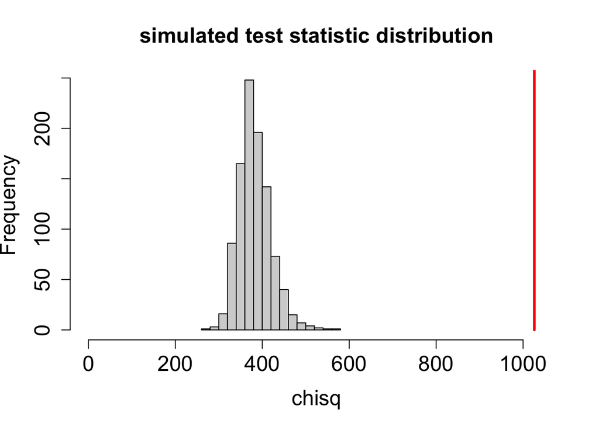

```r
hist(sims@t.star[,1], xlab = 'chisq',
     main = 'simulated test statistic distribution',
     xlim = c(0, 1050),
     cex.axis = 1.5, cex.lab = 1.5, cex.main = 1.5)
lines(x = rep(chisq(fit), 2),
      y = c(0,1000),
      col = 'red', lwd = 3)
```

```r
sum(sims@t.star[,1] > chisq(fit)) / 1000
```

```
## [1] 0
```